# R Notebook

# 0 Set up environment, load packages and data

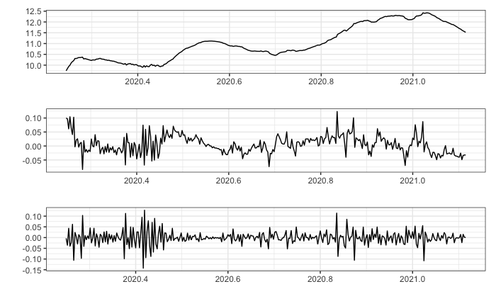

```r
rm(list = ls())
set.seed(1)

# Set paths
root <- paste0("/Users/tombearpark/Documents/princeton/",
               "1st_year/term2/ECO518_Metrics2/")
dir <- paste0(root, "sims/exercises/3_AR/")
out <- paste0(dir, "out/")
setwd(dir)

# Load packages
if(!require(IDex2019))
  install.packages("IDex2019", repos = NULL, type = "source")
if(!require(pacman)) install.packages("pacman")
pacman::p_load(IDex2019, tidyverse, ggfortify, patchwork, zoo)
theme_set(theme_bw())
# Load data, and plot a simple time series
load("logcovidcases.RData")
df <- cfd19ts

# Note - doesn't look very stationary! Neither do the differences
autoplot(df) /
autoplot(diff(df)) /
autoplot(diff(df, differences = 2))
```

```r
# Save in a convenient format for later plotting
plot_df <- df %>% as.data.frame() %>%
  mutate(date = row_number() - length(df))
```

# 1. Fit a 9th order linear AR model to the data.

Estimation of the model can be done with a call to rfvar3(). By default rfvar3() uses an improper prior that shrinks toward persistence. You can omit that prior by setting lambda=NULL, mu=NULL. You can choose whether or not to use the prior.

```r
# ?rfvar3
AR9 <- rfvar3(
  ydata = df,
  lags = 9,
  xdata = NULL,
  const = TRUE,
  breaks = NULL,
  lambda = NULL,
  mu = NULL,
  ic = NULL,
  sigpar = NULL)

# Check I can get the same thing in base R
baseR_AR <- ar(df, aic = FALSE, order.max = 9, method = "ols")
data.frame(sims = AR9$By[,,seq(1, dim(AR9$By)[3])],
                       baseR = baseR_AR$ar)
```

|  | sims | baseR |
| --- | --- | --- |
| 1 | 1.233095111 | 1.233095111 |
| 2 | 0.018438252 | 0.018438252 |
| 3 | -0.065427731 | -0.065427731 |
| 4 | -0.076003362 | -0.076003362 |
| 5 | -0.002085195 | -0.002085195 |
| 6 | -0.041047493 | -0.041047493 |
| 7 | -0.445553401 | -0.445553401 |
| 8 | 0.531587672 | 0.531587672 |
| 9 | -0.154845942 | -0.154845942 |

# 2. Forecast the next 270 days, using the estimates

The y0 agument of the forecasting commands should be dimensioned as a 9 x 1 matrix. It should also be a time series object with start date and frequency. Check that this is true with str(y0). If not,use y0 <-ts(matrix(y0, ncol=1), end=c(2021,42), freq=365). The c(2021, 42) specifies day 42 (i.e.February11) of 2021.

```r
# Format initial condition
y0 <- df[(length(df) - 8):length(df)]
y0 <- ts(matrix(y0, ncol=1),
        end=c(2021,42),
        freq=365)
str(y0)
```

```
 Time-Series [1:9, 1] from 2021 to 2021: 11.8 11.8 11.7 11.7 11.7 ...
 - attr(*, "dimnames")=List of 2
  ..$ : NULL
  ..$ : chr "Series 1"
```

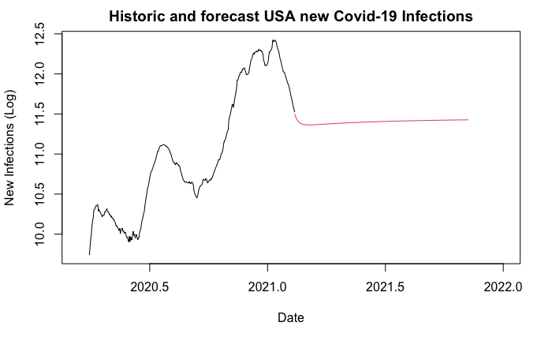

```r
# A forecast using a single set of parameter values can be generated with
# fcast()

f <- fcast(y0 = y0,         # values of time series to forecast from
           By = AR9$By,     # fitted AR coefficients from part 1
           Bx = AR9$Bx,
           xdata = NULL,    # exogenous variables (we don't have any)
           horiz = 270,     # forecast horizon
           const = TRUE,
           shocks = NULL
           )

# Plot!
f <- window(f, start = c(2021,43))
ts.plot(df, xlim = (c(2020.2, 2022)),
        main = "Historic and forecast USA new Covid-19 Infections",
        ylab = "New Infections (Log)", xlab = "Date")
points(f, type = "l", col = 2)
```